# Using dplyr to manipulate data sets

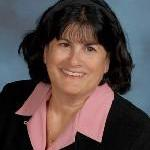

By Dr. Charles Redmond, documented by Judy Minichelli (pictured)

dplyr allows filtering of dataset columns and rows by using “select” and “filter”" commands. Output can be arranged in ascending or descending order. Aggregation, or summarizing, can also be performed.

The Lahman baseball database will be used to show examples of filtering, arranging and aggregation. First, import the Lahman and dplyr packages.

```r
library(Lahman)
library(dplyr)
```

# Filtering Columns and Rows——————————————

The Lahman baseball database can be filtered to display any attributes, for example number of homeruns, for selected teams and years.

### Example 1

Show homerun totals for the 1927 New York Yankees:

```r
Batting%>%
  select(playerID,yearID,teamID,HR)%>%
  filter(teamID=='NYA'& yearID==1927)
```

```
##     playerID yearID teamID HR
## 1  beallwa01   1927    NYA  0
## 2  bengobe01   1927    NYA  0
## 3  collipa01   1927    NYA  7
## 4  combsea01   1927    NYA  6
## 5  duganjo01   1927    NYA  2
## 6  durstce01   1927    NYA  0
## 7  gazelmi01   1927    NYA  0
## 8  gehrilo01   1927    NYA 47
## 9  giardjo01   1927    NYA  0
## 10 grabojo01   1927    NYA  0
## 11  hoytwa01   1927    NYA  0
## 12 koenima01   1927    NYA  3
## 13 lazzeto01   1927    NYA 18
## 14 meusebo01   1927    NYA  8
## 15 moorewi01   1927    NYA  1
## 16 morehra01   1927    NYA  1
## 17 paschbe01   1927    NYA  2
## 18 pennohe01   1927    NYA  0
## 19 pipgrge01   1927    NYA  1
## 20 ruethdu01   1927    NYA  1
## 21  ruthba01   1927    NYA 60
## 22 shawkbo01   1927    NYA  0
## 23 shockur01   1927    NYA  0
## 24 thomamy01   1927    NYA  0
## 25  weraju01   1927    NYA  1
```

### Example 2

Show all instances where New York Yankee players hit over 40 homeruns:

```r
Batting%>%
  filter(HR>=40 & teamID=='NYA')%>%
  select(playerID,yearID,teamID,HR)
```

```
##     playerID yearID teamID HR
## 1   ruthba01   1920    NYA 54
## 2   ruthba01   1921    NYA 59
## 3   ruthba01   1923    NYA 41
## 4   ruthba01   1924    NYA 46
## 5   ruthba01   1926    NYA 47
## 6  gehrilo01   1927    NYA 47
## 7   ruthba01   1927    NYA 60
## 8   ruthba01   1928    NYA 54
## 9   ruthba01   1929    NYA 46
## 10 gehrilo01   1930    NYA 41
## 11  ruthba01   1930    NYA 49
## 12 gehrilo01   1931    NYA 46
## 13  ruthba01   1931    NYA 46
## 14  ruthba01   1932    NYA 41
```

[output cut: 16 more lines]

### Example 3

```r
Batting%>%
  select(playerID,yearID, teamID,HR,SO)%>%
  filter(HR>40 & SO>60)
```

```
##      playerID yearID teamID HR  SO
## 1    ruthba01   1920    NYA 54  80
## 2    ruthba01   1921    NYA 59  81
## 3    ruthba01   1923    NYA 41  93
## 4    ruthba01   1924    NYA 46  81
## 5    ruthba01   1926    NYA 47  76
## 6   gehrilo01   1927    NYA 47  84
## 7    ruthba01   1927    NYA 60  89
## 8    ruthba01   1928    NYA 54  87
## 9   kleinch01   1929    PHI 43  61
## 10  gehrilo01   1930    NYA 41  63
## 11   ruthba01   1930    NYA 49  61
## 12  wilsoha01   1930    CHN 56  84
## 13   foxxji01   1932    PHA 58  96
## 14   ruthba01   1932    NYA 41  62
```

[output cut: 228 more lines]

# Arranging——————————————————————

Results can be displayed in ascending or descending order. The default is ascending order.

### Example 1

Show all instances where players hit >50 in descending order:

```r
Batting%>%
  select(playerID,yearID,teamID,HR)%>%
  filter(HR>50)%>%
  arrange(desc(HR))
```

```
##     playerID yearID teamID HR
## 1  bondsba01   2001    SFN 73
## 2  mcgwima01   1998    SLN 70
## 3   sosasa01   1998    CHN 66
## 4  mcgwima01   1999    SLN 65
## 5   sosasa01   2001    CHN 64
## 6   sosasa01   1999    CHN 63
## 7  marisro01   1961    NYA 61
## 8   ruthba01   1927    NYA 60
## 9   ruthba01   1921    NYA 59
## 10  foxxji01   1932    PHA 58
## 11 greenha01   1938    DET 58
## 12 howarry01   2006    PHI 58
## 13 gonzalu01   2001    ARI 57
## 14 rodrial01   2002    TEX 57
```

[output cut: 22 more lines]

### Example 2

Show all instances of a player striking out less than 10 times but had more than 400 at bats:

```r
Batting%>%
  select(playerID,yearID,teamID,SO, AB)%>%
  filter(SO<10 & AB>=400)%>%
  arrange(SO)
```

```
##     playerID yearID teamID SO  AB
## 1  doyleja01   1894    NY1  3 422
## 2  seweljo01   1932    NYA  3 503
## 3  seweljo01   1925    CLE  4 608
## 4  seweljo01   1929    CLE  4 578
## 5  seweljo01   1933    NYA  4 524
## 6   wardjo01   1893    NY1  5 588
## 7  holloch01   1922    CHN  5 592
## 8  mcinnst01   1922    CLE  5 537
## 9  wanerll01   1936    PIT  5 414
## 10 wrighge01   1875    BS1  6 408
## 11 broutda01   1889    BSN  6 485
## 12 keelewi01   1894    BLN  6 590
## 13  wardjo01   1894    NY1  6 540
## 14 quinnjo02   1895    SLN  6 543
```

[output cut: 51 more lines]

### Example 3

Show all instances of a Philly player with >30 HRs between years 1970 and 1979:

```r
Batting%>%
  select(playerID,yearID,teamID,HR)%>%
  filter(teamID=='PHI' & HR>30 & yearID<=1979 & yearID>=1970)
```

```
##    playerID yearID teamID HR
## 1 johnsde01   1971    PHI 34
## 2 schmimi01   1974    PHI 36
## 3 luzingr01   1975    PHI 34
## 4 schmimi01   1975    PHI 38
## 5 schmimi01   1976    PHI 38
## 6 luzingr01   1977    PHI 39
## 7 schmimi01   1977    PHI 38
## 8 luzingr01   1978    PHI 35
## 9 schmimi01   1979    PHI 45
```

# Aggregating—————————————————————–

### Example 1

Show the number of career homeruns by Babe Ruth:

```r
Batting%>%
  filter(playerID=='ruthba01')%>%
  group_by(playerID)%>%
  summarize(career_HR=sum(HR))
```

```
## # A tibble: 1 x 2
##   playerID career_HR
##      <chr>     <int>
## 1 ruthba01       714
```

### Example 2

```r
Batting%>%
  group_by(playerID)%>%
  summarize(career_HR=sum(HR))%>%
  filter(career_HR>='600')%>%
  arrange(desc(career_HR))
```

```
## # A tibble: 1,004 x 2
##     playerID career_HR
##        <chr>     <int>
##  1 bondsba01       762
##  2 aaronha01       755
##  3  ruthba01       714
##  4 rodrial01       696
##  5  mayswi01       660
##  6 griffke02       630
##  7 thomeji01       612
##  8  sosasa01       609
##  9 atkinga01        99
## 10  blumge01        99
## # ... with 994 more rows
```

### Example 3

Show the players that have had greater than 30 average homerun season totals in descending order:

```r
Batting%>%
  group_by(playerID)%>%
  summarize(HRAvg=mean(HR))%>%
  filter(HRAvg>30)%>%
  arrange(desc(HRAvg))
```

```
## # A tibble: 13 x 2
##     playerID    HRAvg
##        <chr>    <dbl>
##  1 pujolal01 36.93750
##  2 bondsba01 34.63636
##  3 mcgwima01 34.29412
##  4 kinerra01 33.54545
##  5 aaronha01 32.82609
##  6 bryankr01 32.50000
##  7  ruthba01 32.45455
##  8  sosasa01 32.05263
##  9 cabremi01 31.85714
## 10 belleal01 31.75000
## 11 rodrial01 31.63636
## 12 schmimi01 30.44444
## 13 abreujo02 30.33333
```

### A Final Example —————————————————————–

Since 1970, which players have hit more than 50 homeruns in a single season at least once?

```r
Batting%>%
  filter(yearID>=1970)%>%
  group_by(playerID)%>%
  summarize(maxHR=max(HR))%>%
  filter(maxHR>50)%>%
  select(playerID)
```

```
## # A tibble: 14 x 1
##     playerID
##        <chr>
##  1 bautijo02
##  2 bondsba01
##  3 davisch02
##  4 fieldce01
##  5 fostege01
##  6 gonzalu01
##  7 griffke02
##  8 howarry01
##  9 jonesan01
## 10 mcgwima01
## 11 ortizda01
## 12 rodrial01
## 13  sosasa01
## 14 thomeji01
```

The End!